# 2020 CRAN Usage

2021-01-04

## Overview

There follows a high-level report on CRAN package downloads. The source data for this report is the [log data made available](https://cran-logs.rstudio.com) from the CRAN mirror service operated by RStudio.

The [RStudio CRAN mirror](https://cran.rstudio.com) is the default mirror used in the IDE. Naturally, the end user is free to change this and not all R users use the RStudio IDE. There are a great many alternate mirrors that an R user may choose to use as well as service’s like RStudio’s own [Public Package Manager](https://packagemanager.rstudio.com). As such, this report should be taken for what it is; a look at the traffic of a large CRAN mirror only and it may therefore not be representative of CRAN usage as a whole.

Methodology - counts have had duplicate values removed, for example, for the R version counts, we have no counted the same user twice for a particular day.

## Total Downloads

In 2020 there were a total of 1,773,286,890 package downloads from the mirror.

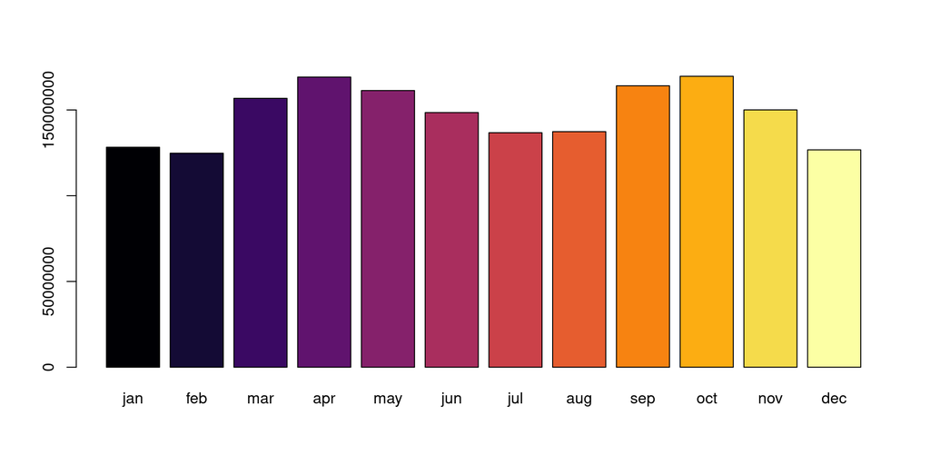

The day with the highest number of package downloads, 7,343,716, was the 28th of April, which makes sense if we remember that R 4.0.0 was released on the 24th of April and it’s likely that users will have been installing packages after the upgrade.

Somewhat less explicably, the day with the lowest recorded number of package downloads, 813,895, was the 29th of February.

Other than those stand-outs, package downloads appear to follow a familliar seasonal pattern of dips in the Nerthern hemisphere’s Summer and Winter.

One interesting point that only become apparent when you plot downloads by day is that there are two clear clusters: one for weekdays and another for weekends. Whilst some of the weekend usage is likely to be work-related and some will be almost certainly be automated processes, I believe the strong weekend usage is indicative of the langauge’s popularity among maintainers of side-projects, learners and hobbyists.

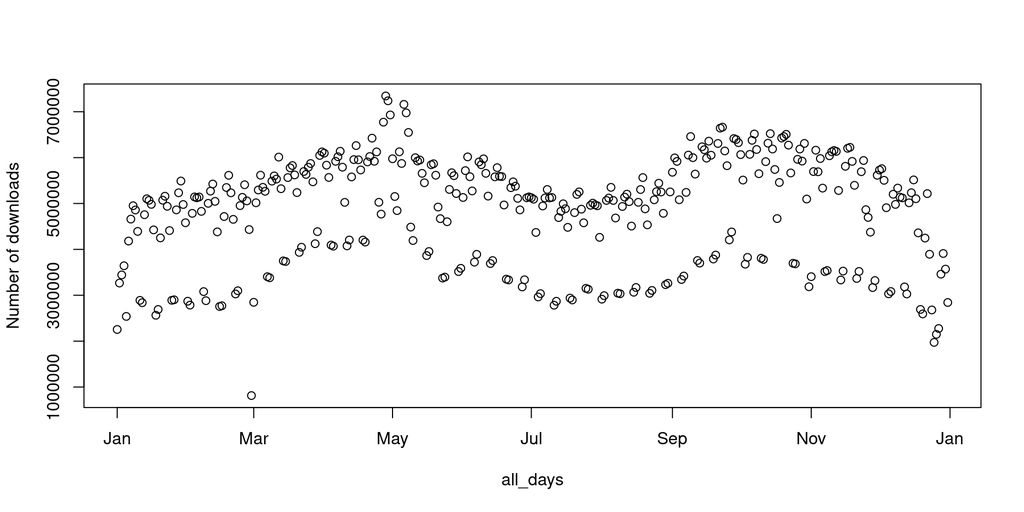

## Most popular packages

### Overview

top 20 packages for each month of the year. As you might anticipate, this list is dominated by some very well known packages as well as much-depended on packages.

It would be interesting to contrast this information with that from other years to pull out any broader trends.

### Jan

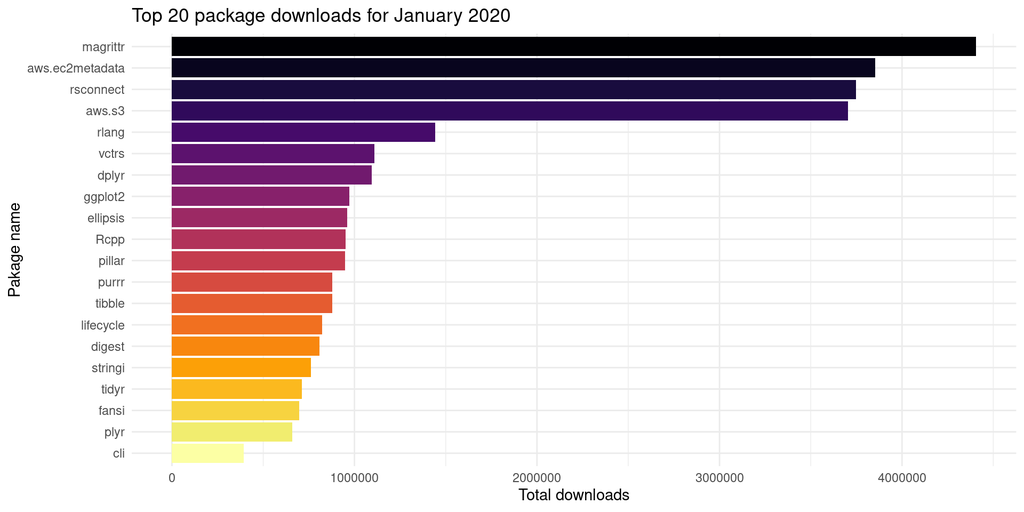

### Feb

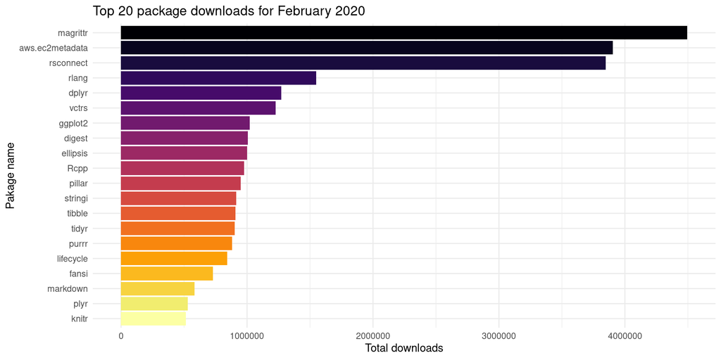

### Mar

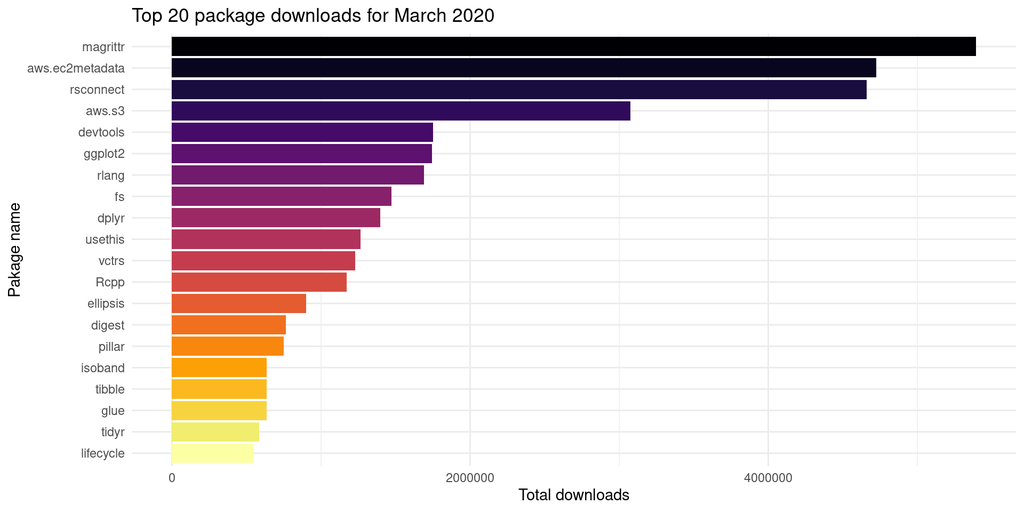

### Apr

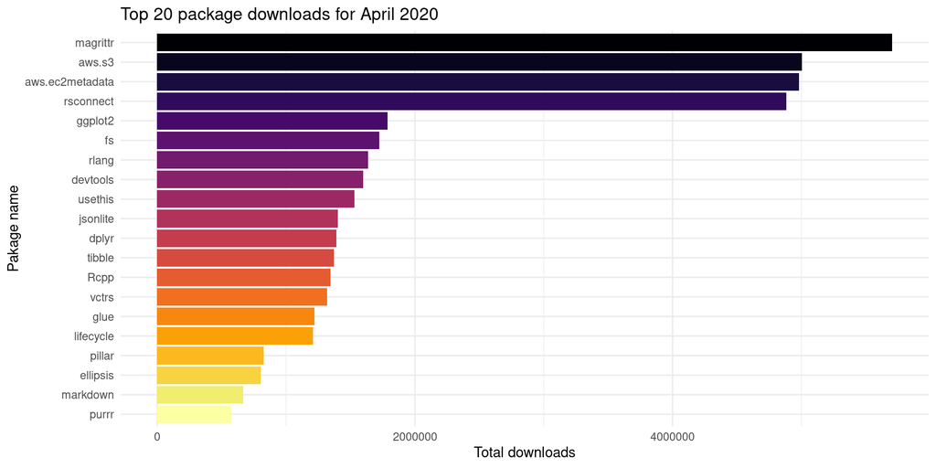

### May

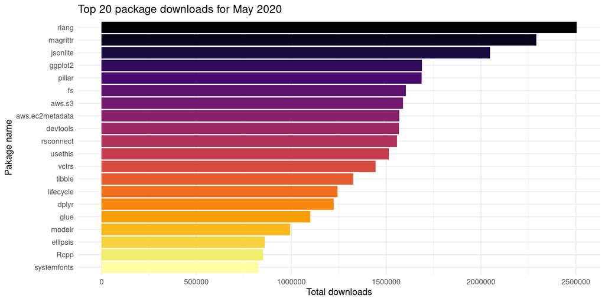

### Jun

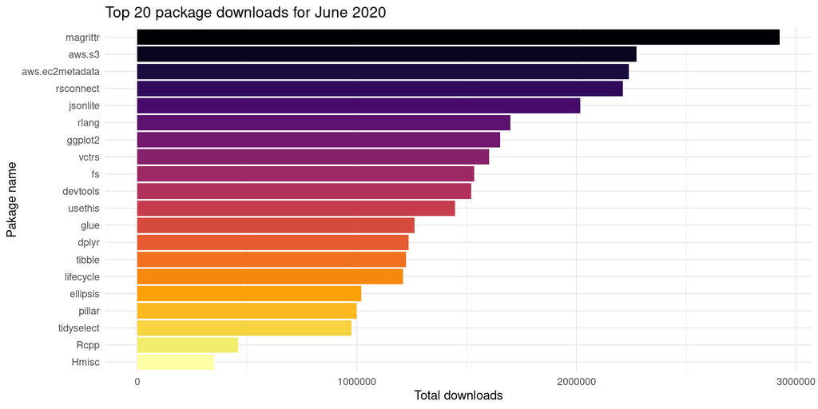

### Jul

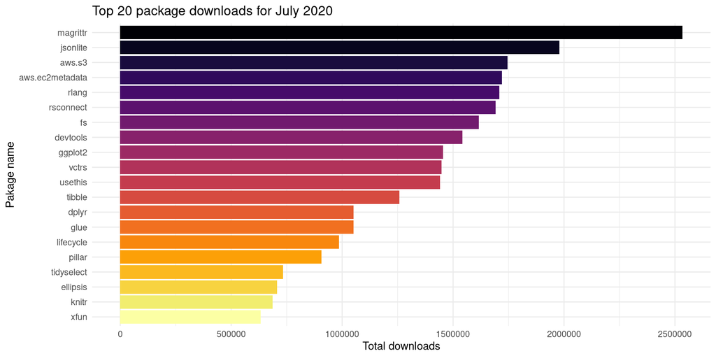

### Aug

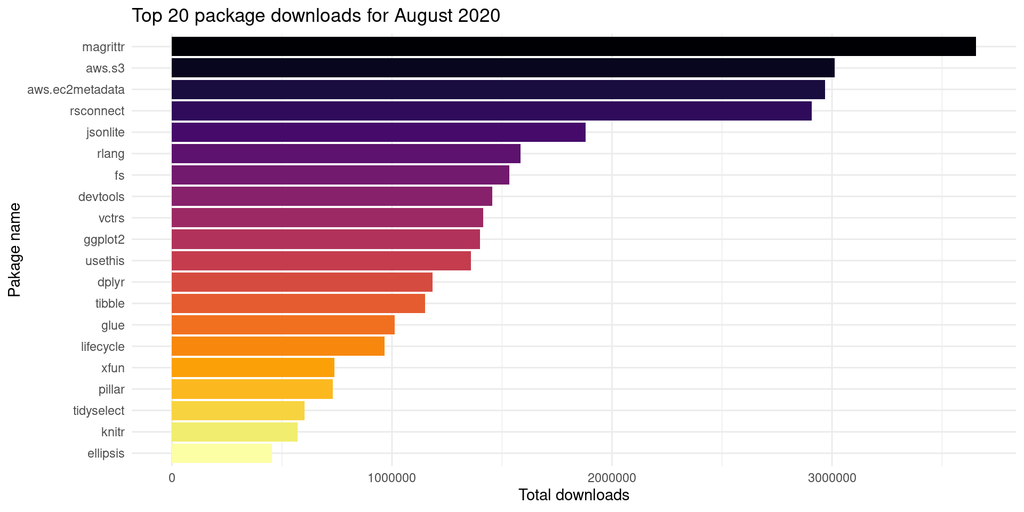

### Sep

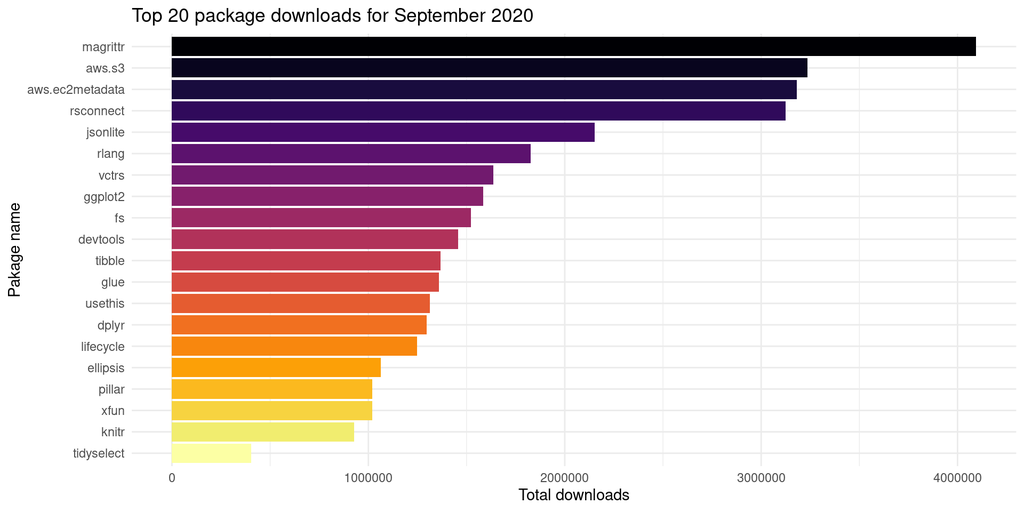

### Oct

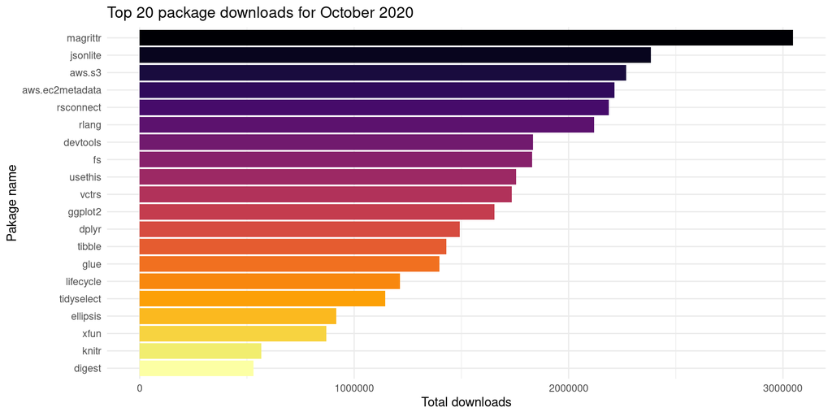

### Nov

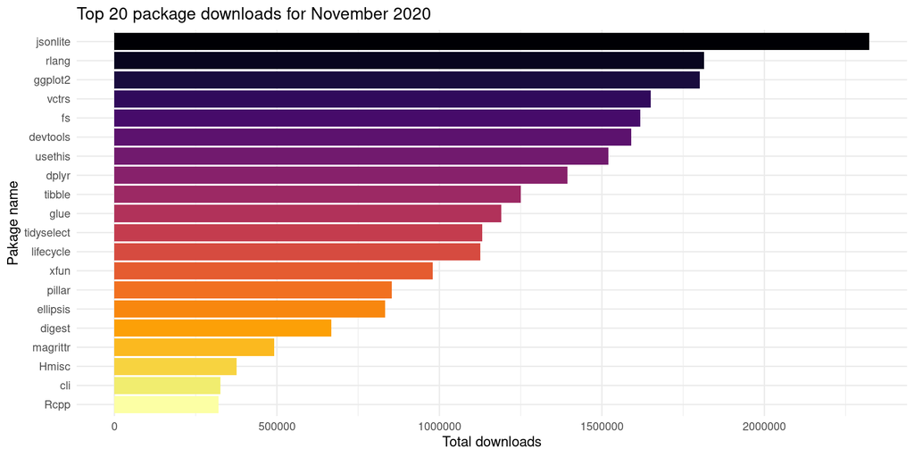

### Dec

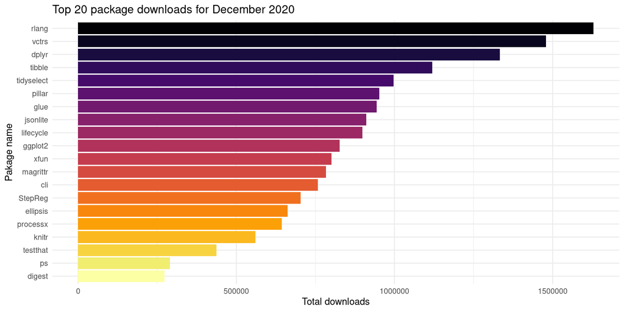

## R versions

Despite the release of R 4 about a third of the way into the year, this version doesn’t even make it into this year’s top 10.

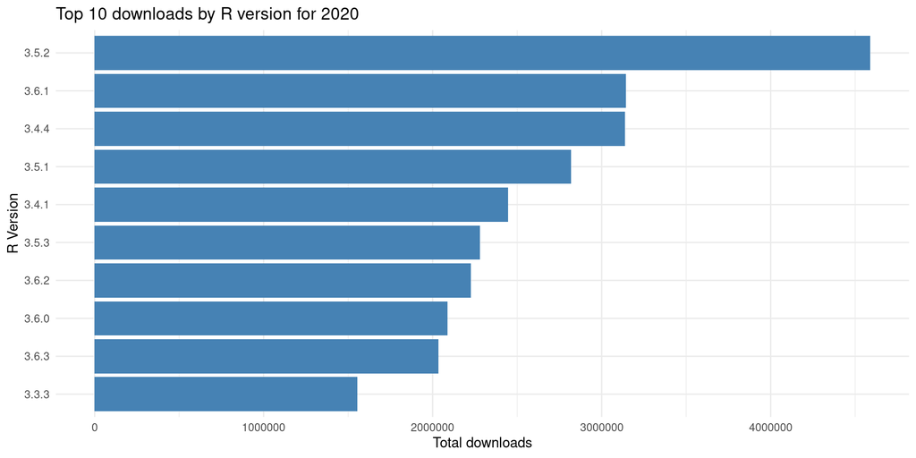

Top R version by month

| Month. | Top R version by number of users | Number of users |
| --- | --- | --- |
| January | 3.6.2 | 520731 |
| February | 3.6.2 | 561421 |
| March | 3.5.2 | 563862 |
| April | 3.5.2 | 537531 |
| May | 3.5.2 | 474200 |
| June | 3.5.2 | 407730 |
| July | 3.5.2 | 352689 |
| August | 3.5.2 | 313722 |
| September | 3.5.2 | 342597 |
| October | 3.5.2 | 346264 |
| November | 3.5.2 | 312316 |
| December | 4.0.3 | 236212 |

The top 10 most used R versions combined usage fell over the course of the year while overall R usage did not. This is likely indicative of the slowly increasing usage in R 4 and above.

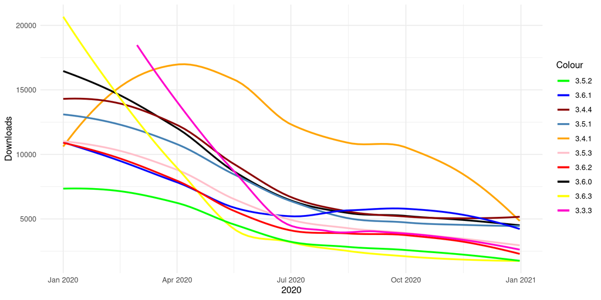

## Countries

Which countries are the heaviest users of R?

No surprises here. The chart is dominated by US based usage, which dwarfs usage in China which takes the number 2 spot.

Though we can’t provide any evidence to suggest that this impacts the results, it’s worth remembering that all three of the planet’s biggest cloud providers are based in the US. As such they have a much larger presence in the US than in other territories and users in other countries will often use US regions for their cloud work in order to better serve US customers and access additional features not yet available in other regions.

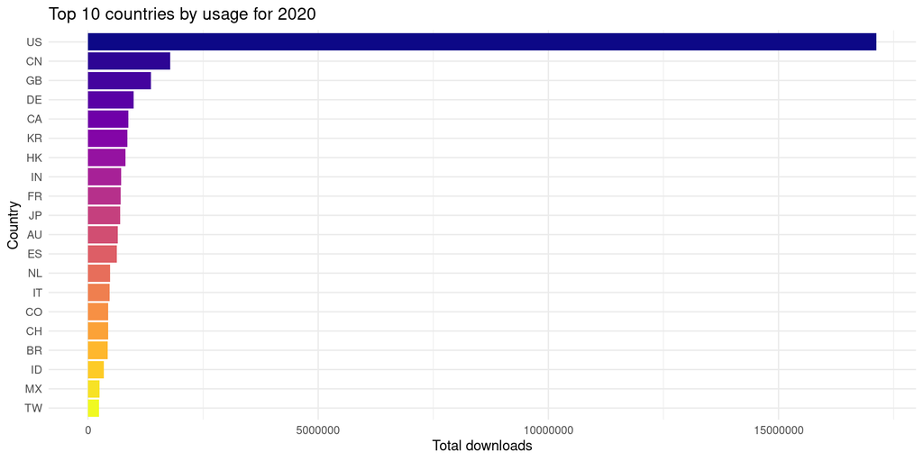

| country | users |
| --- | --- |
| US | 17128551 |
| CN | 1784030 |
| GB | 1366538 |
| DE | 988511 |
| CA | 876119 |
| KR | 854080 |
| HK | 818181 |
| IN | 719696 |
| FR | 710726 |
| JP | 698291 |
| AU | 643163 |
| ES | 629985 |
| NL | 478456 |
| IT | 467305 |
| CO | 438202 |
| CH | 434483 |
| BR | 426706 |
| ID | 338927 |
| MX | 247616 |
| TW | 237934 |

## By OS

Which operating systems do R users use?

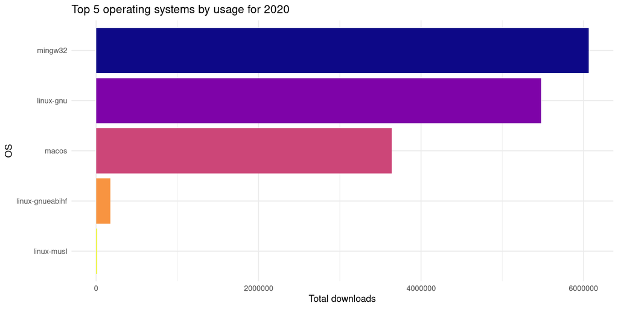

Unsurprisingly, Windows takes the top spot. Linux (linux-gnu) puts in a strong showing, perhaps due to the number of production R systems in use. MacOS, also makes a strong showing (compared to it’s relative market share), likely due to it’s popularity as a development platform amongst R users. Taking the 4th and 5th spots respectively are “linux-gnueabihf”, which seems to be Linux for ARM based CPU’s (which perhaps we’ll see more of in the future) and “linux-musl”, which I believe could be Docker favourite [Alpine Linux](https://alpinelinux.org).

Full results

| os | users |
| --- | --- |
| mingw32 | 6063418 |
| linux-gnu | 5479465 |
| macos | 3638685 |
| linux-gnueabihf | 175928 |
| linux-musl | 14249 |

A few other notable results: There were just short of 400 package downloads from Solaris based systems, Around 250 FreeBSD downloads and about 20 from OpenBSD based hosts.

Another half-baked [sellorm](https://blog.sellorm.com) rought cut.